# M37DS Final Project - Predicting Malignancy/Benignness of Tumors

## K-Nearest Neighbors

Create subsets of the train and test sets using the same 8 variables from the random forest example:

```r
# Subset of training data
train_fna_knn <- train_fna[, c("diagnosis", "radius_worst", "concavity_worst", "texture_se", "area_mean", "perimeter_se", "smoothness_mean", "fractal_dimension_se", "symmetry_mean")]

glimpse(train_fna_knn)
```

```
## Rows: 455
## Columns: 9
## $ diagnosis            <fct> M, M, M, M, M, M, M, M, M, M, M, M, M, M, M, M, M…
## $ radius_worst         <dbl> 0.62077552, 0.60690146, 0.55638563, 0.24831021, 0…
## $ concavity_worst      <dbl> 0.56861022, 0.19297125, 0.35974441, 0.54864217, 0…
## $ texture_se           <dbl> 0.12046941, 0.08258929, 0.09430251, 0.17587518, 0…
## $ area_mean            <dbl> 0.36373277, 0.50159067, 0.44941676, 0.10290562, 0…
## $ perimeter_se         <dbl> 0.36903360, 0.12444047, 0.18037035, 0.12665504, 0…
## $ smoothness_mean      <dbl> 0.5937528, 0.2898799, 0.5143089, 0.8113208, 0.678…
## $ fractal_dimension_se <dbl> 0.18304244, 0.09111010, 0.12700551, 0.28720479, 0…
## $ symmetry_mean        <dbl> 0.6863636, 0.3797980, 0.5095960, 0.7762626, 0.518…
```

```r
# Subset of testing data
test_fna_knn <- test_fna[, c("diagnosis", "radius_worst", "concavity_worst", "texture_se", "area_mean", "perimeter_se", "smoothness_mean", "fractal_dimension_se", "symmetry_mean")]

glimpse(test_fna_knn)
```

```
## Rows: 114
## Columns: 9
## $ diagnosis            <fct> M, B, B, M, B, M, M, M, B, B, B, B, B, B, B, B, B…
## $ radius_worst         <dbl> 0.51974386, 0.25080043, 0.06414088, 0.89647812, 0…
## $ concavity_worst      <dbl> 0.31948882, 0.20583067, 0.11453674, 0.51525559, 0…
## $ texture_se           <dbl> 0.09306489, 0.03047649, 0.10873409, 0.10844678, 0…
## $ area_mean            <dbl> 0.48928950, 0.17722163, 0.04262990, 0.79172853, 0…
## $ perimeter_se         <dbl> 0.22056260, 0.05908684, 0.11360317, 0.30462234, 0…
## $ smoothness_mean      <dbl> 0.4303512, 0.4736842, 0.4080527, 0.5621558, 0.267…
## $ fractal_dimension_se <dbl> 0.14579965, 0.06989760, 0.72672498, 0.08603154, 0…
## $ symmetry_mean        <dbl> 0.3782828, 0.4555556, 0.4252525, 0.4525253, 0.142…
```

Plot the train and test error rates to spot most promising k-values:

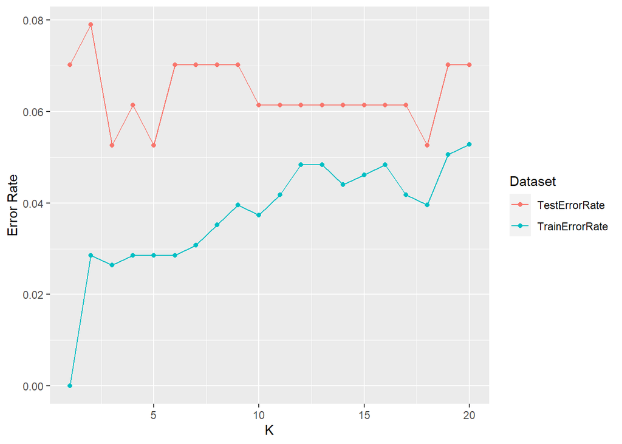

```r
# Define the range of K values
k_values <- 1:20

# Initialize an empty vector to store the error rates
train_error_rates <- numeric(length(k_values))
test_error_rates <- numeric(length(k_values))

# Perform k-nearest neighbors classification for each K value
for (i in k_values) {
  train_predictions <- knn(train = train_fna_knn[, 2:9], test = train_fna_knn[, 2:9], cl = train_fna_knn$diagnosis, k = i)
  train_error_rates[i] <- mean(train_predictions != train_fna_knn$diagnosis)

  test_predictions <- knn(train = train_fna_knn[, 2:9], test = test_fna_knn[, 2:9], cl = train_fna_knn$diagnosis, k = i)
  test_error_rates[i] <- mean(test_predictions != test_fna_knn$diagnosis)
}

# Create a data frame with K, train error rates, and test error rates
error_df <- data.frame(K = k_values, TrainErrorRate = train_error_rates, TestErrorRate = test_error_rates)

# Convert the data frame from wide to long format
error_df_long <- tidyr::gather(error_df, "Dataset", "ErrorRate", -K)

# Plot the error rates against K
ggplot(data = error_df_long, aes(x = K, y = ErrorRate, color = Dataset)) +
  geom_line() +
  geom_point() +
  labs(x = "K", y = "Error Rate", color = "Dataset")
```

```r
set.seed(1842)
```

k = 16 jumps out with the narrowest gap! We’ll try 16, as as well as nearby values of k = 13 and k = 18:

```r
# k = 16
fna_knn_pred_16 <- knn(train = train_fna_knn[,2:9], test = test_fna_knn[,2:9], cl = train_fna_knn$diagnosis, k = 16)

# Create the confusion matrix.
knn_conf_16 <- table(fna_knn_pred_16, test_fna_knn$diagnosis)
knn_conf_16
```

```
##
## fna_knn_pred_16  B  M
##               B 69  5
##               M  2 38
```

```r
cat("Accuracy: ", sum(diag(knn_conf_16)) / sum(knn_conf_16))
```

```
## Accuracy:  0.9385965
```

```r
# k = 18
fna_knn_pred_18 <- knn(train = train_fna_knn[,2:9], test = test_fna_knn[,2:9], cl = train_fna_knn$diagnosis, k = 18)

# Create the confusion matrix.
knn_conf_18 <- table(fna_knn_pred_18, test_fna_knn$diagnosis)
knn_conf_18
```

```
##
## fna_knn_pred_18  B  M
##               B 69  5
##               M  2 38
```

```r
cat("Accuracy: ", sum(diag(knn_conf_18)) / sum(knn_conf_18))
```

```
## Accuracy:  0.9385965
```

```r
# k = 13
fna_knn_pred_13 <- knn(train = train_fna_knn[,2:9], test = test_fna_knn[,2:9], cl = train_fna_knn$diagnosis, k = 13)

# Create the confusion matrix.
knn_conf_13 <- table(fna_knn_pred_13, test_fna_knn$diagnosis)
knn_conf_13
```

```
##
## fna_knn_pred_13  B  M
##               B 69  5
##               M  2 38
```

```r
cat("Accuracy: ", sum(diag(knn_conf_13)) / sum(knn_conf_13))
```

```
## Accuracy:  0.9385965
```

All values of k give the same accuracy of 93.9%, complete with identical confusion matrices. Choose k = 16 given the original errors plot.

## Wrap-up

```r
# Calculate performance metrics for confusion_rw
accuracy_rw <- sum(diag(confusion_rw)) / sum(confusion_rw)
precision_rw <- confusion_rw[2, 2] / sum(confusion_rw[, 2])
recall_rw <- confusion_rw[2, 2] / sum(confusion_rw[2, ])
specificity_rw <- confusion_rw[1, 1] / sum(confusion_rw[1, ])
f1_score_rw <- 2 * (precision_rw * recall_rw) / (precision_rw + recall_rw)

# Calculate performance metrics for confusion_rf
accuracy_rf <- sum(diag(confusion_rf)) / sum(confusion_rf)
precision_rf <- confusion_rf[2, 2] / sum(confusion_rf[, 2])
recall_rf <- confusion_rf[2, 2] / sum(confusion_rf[2, ])
specificity_rf <- confusion_rf[1, 1] / sum(confusion_rf[1, ])
f1_score_rf <- 2 * (precision_rf * recall_rf) / (precision_rf + recall_rf)

# Calculate performance metrics for knn_conf_16
accuracy_knn <- sum(diag(knn_conf_16)) / sum(knn_conf_16)
precision_knn <- knn_conf_16[2, 2] / sum(knn_conf_16[, 2])
recall_knn <- knn_conf_16[2, 2] / sum(knn_conf_16[2, ])
specificity_knn <- knn_conf_16[1, 1] / sum(knn_conf_16[1, ])
f1_score_knn <- 2 * (precision_knn * recall_knn) / (precision_knn + recall_knn)

# Create the table
metrics_table <- data.frame(Metric = c("Accuracy", "Precision", "Recall", "Specificity", "F1 Score"),
                            confusion_rw = c(accuracy_rw, precision_rw, recall_rw, specificity_rw, f1_score_rw),
                            confusion_rf = c(accuracy_rf, precision_rf, recall_rf, specificity_rf, f1_score_rf),
                            knn_conf_16 = c(accuracy_knn, precision_knn, recall_knn, specificity_knn, f1_score_knn))

# Print the table
print(metrics_table)
```

```
##        Metric confusion_rw confusion_rf knn_conf_16
## 1    Accuracy    0.9473684    0.9462863   0.9385965
## 2   Precision    1.0000000    0.9743590   0.8837209
## 3      Recall    0.8604651    0.8813376   0.9500000
## 4 Specificity    1.0000000    0.9857200   0.9324324
## 5    F1 Score    0.9250000    0.9255169   0.9156627
```

All models have comparable accuracy and F1 scores, within a 1% range. K-nearest neighbors notably under-performs the others on precision (positive predicitive value, i.e., true positives out of predicted positives), and specificity (true negative rate) but outperforms them on recall (true positive rate).

Recomendation: the K-nearest neighbors model appears to be the best performer under the circumstances. Given the nature of the diagnosis, it seems desirable to minimize false negatives (i.e., via high recall), to help ensure that malignant tumors are identified more reliably and treated as early as possible. Sacrificing a lower false positive rate seems to be a reasonable trade-off, given that a patient is more likely to seek a second opinion for a false positive than for a false negative.